# Bayes Hierarchical Model

Brinkley Raynor

4/29/2022

## Data

The data here is extracted dates from focus control reports. These are the reports ascertaining the epidemiologic history of positive canine rabies cases.For the purposes of this analysis, infectious period (CullLag) is defined as the time between initial signs onset and death.

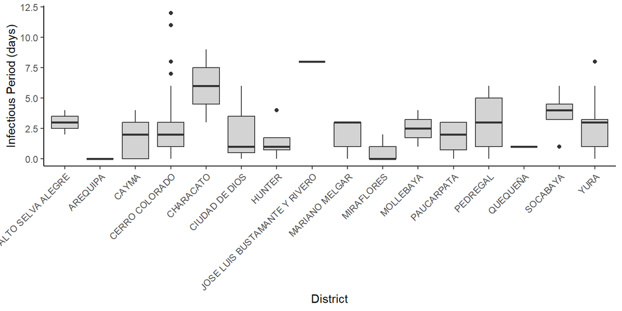

```r
#clean environment
rm(list = ls())

#call packages
library(dplyr) #tidy coding
library(ggplot2) #pretty figures

#Read in data
df.fc<- readRDS(here::here("data_minimal", "DeathTime.Rda"))
```

**Figure 1: Boxplot visualization of infectious period (dog euthanasia date - initial rabies signs date) distribution by district**

## Model formulation

### Gibbs Sampler

```r
set.seed(123)
#GIBBS SAMPLER FUNCTION
fun.gibbs <- function(numsamp, sigsq, tausq, mu0, df){
  df.fc <- df

  #Format data
  df.district = df.fc %>% dplyr::select(id, District, CullLag)%>%
    group_by(District) %>%
    summarise(mean = mean(CullLag, na.rm=TRUE), n = n())

  #Calculate statistics
  means=df.district$mean
  n=df.district$n
  m <- length(means)
  ntot <- sum(n)

  #Set up frames to hold data
  sigsq.samp <- rep(NA,numsamp)
  tausq.samp <- rep(NA,numsamp)
  mu0.samp <- rep(NA,numsamp)
  mu.samp <- matrix(NA,nrow=numsamp,ncol=m)
  mu <- rep(NA,m)

  #Gibbs sampler
  for (i in 1:numsamp){
     # sampling mu's
     for (j in 1:m){
      curvar <- 1/(n[j]/sigsq + 1/tausq)
          curmean <- (means[j]*n[j]/sigsq + mu0/tausq)*curvar
          mu[j] <- rnorm(1,mean=curmean,sd=sqrt(curvar))
     }

     # sampling mu0
     #mu0 <- rnorm(1,mean=mean(mu),sd=sqrt(tausq/m))
     mu0 <- rgamma(1,shape=sqrt(tausq/m), rate=sqrt(tausq/m)/mean(mu))

    # sampling tausq
     sumsq.mu <- sum((mu-mu0)^2)
     tausqinv <- rgamma(1,shape=((m-1)/2),rate=(sumsq.mu/2))
     tausq <- 1/tausqinv
     # sampling sigsq
     sumsq.y <- 0
     for (j in 1:m){
        district <- df.district$District[j]
        y <- df.fc%>% filter(District == district)%>%select(CullLag)%>%na.omit()
        sumsq.y <- sumsq.y + sum((y-mu[j])^2)
     }
      sigsqinv <- rgamma(1,shape=(ntot/2),rate=(sumsq.y/2))

      sigsq <- (1/sigsqinv)


     # storing sampled values
     mu.samp[i,] <- mu
     mu0.samp[i] <- mu0
     tausq.samp[i] <- tausq
     sigsq.samp[i] <- sigsq
  }

  #store to global env
  mu.samp <<- mu.samp
  parm.samp <<- data.frame(mu0.samp = mu0.samp,
                          tausq.samp = tausq.samp,
                          sigsq.samp = sigsq.samp)

}
```

## Model implementation

To implement a Gibbs sampler, starting values of $\mu_0$, $\tau^2$, $\sigma^2$ were arbitrarily selected and then these parameters as well as $\mu_j$ were iteratively updated.

### Confirm convergence

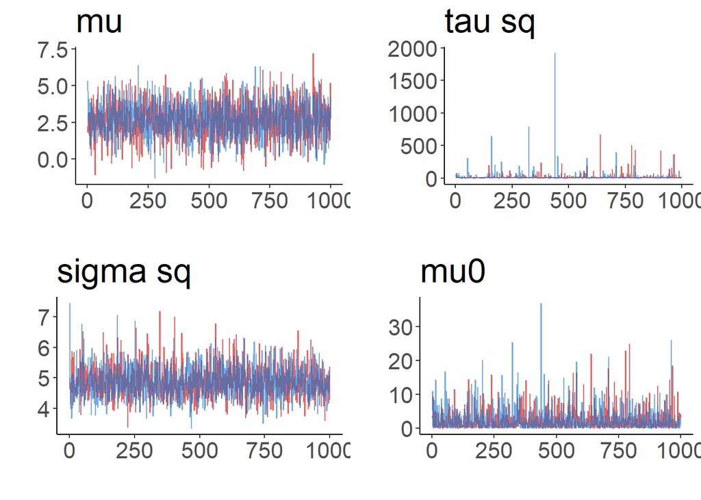

```r
#RUN GIBBS SAMPLER
#function: fun.gibbs(numsamp, sigsq, tausq, mu0, df)
fun.gibbs(1000, 1, 1, 1, df.fc); mu.samp1 <- mu.samp; parm.samp1 <- parm.samp #first chain
fun.gibbs(1000, 10, 10, 20, df.fc); mu.samp2 <- mu.samp; parm.samp2 <- parm.samp #second chain
```

**Figure 2: Global convergence evaluation.**

After convergence was confirmed, burn in time was evaluated. The first 100 samples of both chains were plotted to estimate a burn in time (ie time until the chains converge). The first 20 samples were removed as burn in.

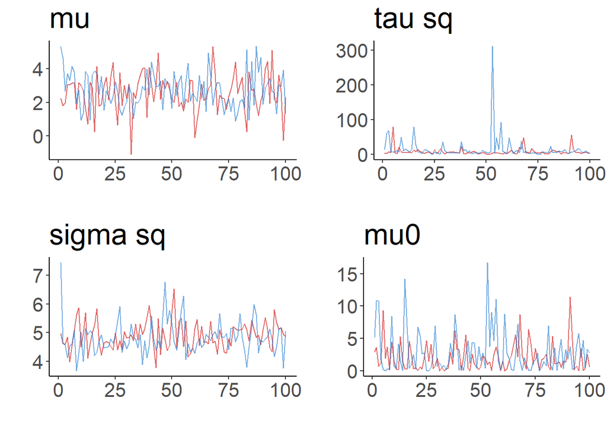

**Figure 3: Burn in evaluation.**

```r
### throwing away first 20 as burn-in
mu.samp1 <- mu.samp1[21:nrow(mu.samp1),]
mu.samp2 <- mu.samp2[21:nrow(mu.samp2),]
parm.samp1 <- parm.samp1[21:nrow(parm.samp1),]
parm.samp2 <- parm.samp2[21:nrow(parm.samp2),]
```

### Evaluate and eliminate autocorrelation

Both chains were evaluated for autocorrelation.

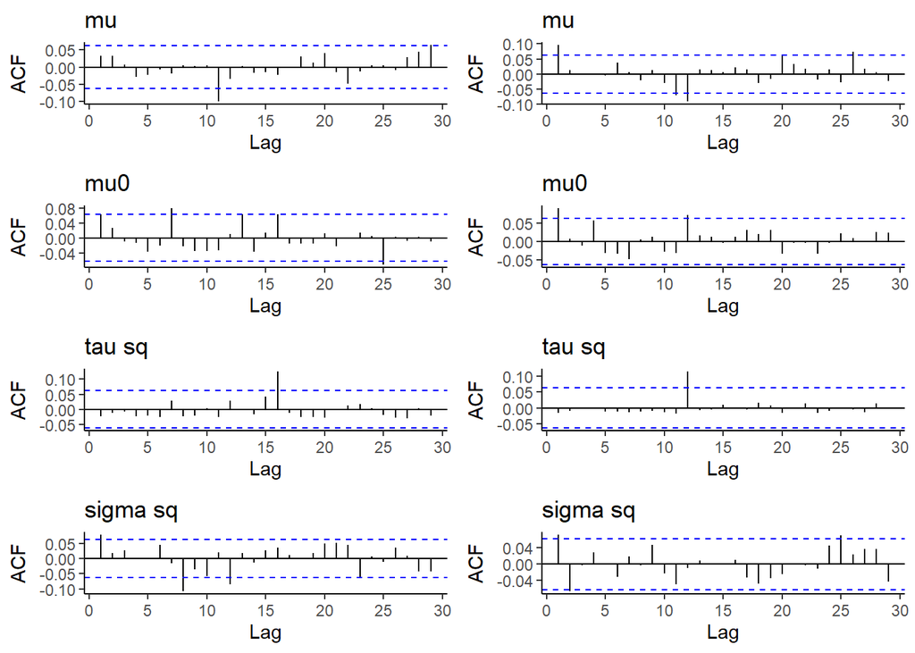

**Figure 4: Initial autocorrelation evaluation.**

In order to produce independent samples, the chains were thinned to remove autocorrelation: 1 out of every 10 samples was kept. After thinning, autocorrelation was re-evaluatedto ensure non-autocorrelated samples.

```r
# thinning chains
Thin <- 10
temp <- Thin*c(1:(nrow(mu.samp2)/Thin))
mu.samp1 <- mu.samp1[temp,]
mu.samp2 <- mu.samp2[temp,]
parm.samp1 <- parm.samp1[temp,]
parm.samp2 <- parm.samp2[temp,]
```

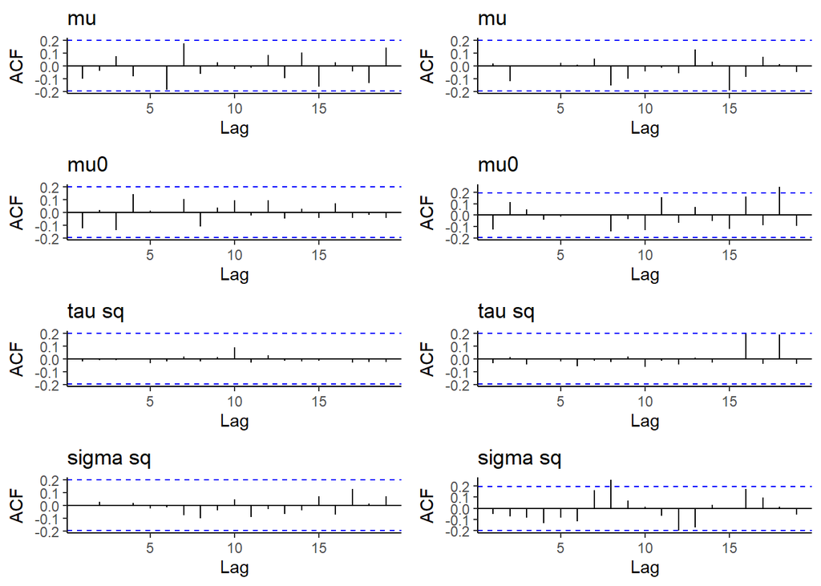

**Figure 5: Autocorrelation evaluation after thinning.**

After thinning, chains were merged into a combined posterior sample set.

```r
#FINAL SAMPLE

#combine chains
mu.samp <- rbind(mu.samp1,mu.samp2)
parm.samp <- rbind(parm.samp1, parm.samp2)

# Calculate statistics
df.district = df.fc %>% select(id, District, CullLag)%>%
  group_by(District) %>%
  summarise(mean = mean(CullLag, na.rm=TRUE), n = n())

df.post <- data.frame(district = df.district$District,
                      means=df.district$mean,
                      n= df.district$n,
                      mu.postmean =apply(mu.samp,2,mean),
                      mu0.postmean=mean(parm.samp$mu0.samp))%>%
  mutate(means = round(means, 2),
         mu.postmean = round(mu.postmean,2))
```

## Results

**Table 1: Means and 95% posterior intervals of global parameters**

| Parameter | Mean | Lower | Upper |
| --- | --- | --- | --- |
| mu0 | 2.31 | 0.00 | 9.89 |
| sigma sq | 4.91 | 3.93 | 6.14 |
| tau sq | 14.79 | 1.48 | 78.20 |

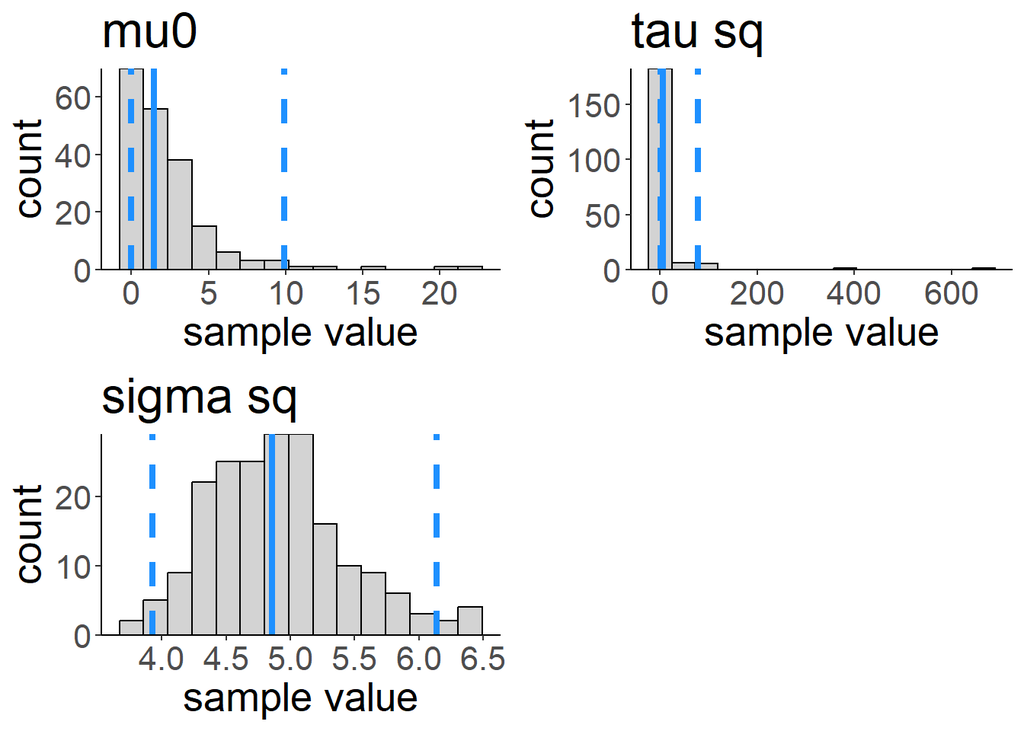

The modeled $\mu$’s were then compared to the data means. Due to the hierarchical model nature, the means with less data supporting it, such as the case of the Jose Luis Bustamante y R. district were pulled dramatically towards the global mean, while districts with a lot of data support, such as the district of Cerro Colorado were barely budged.

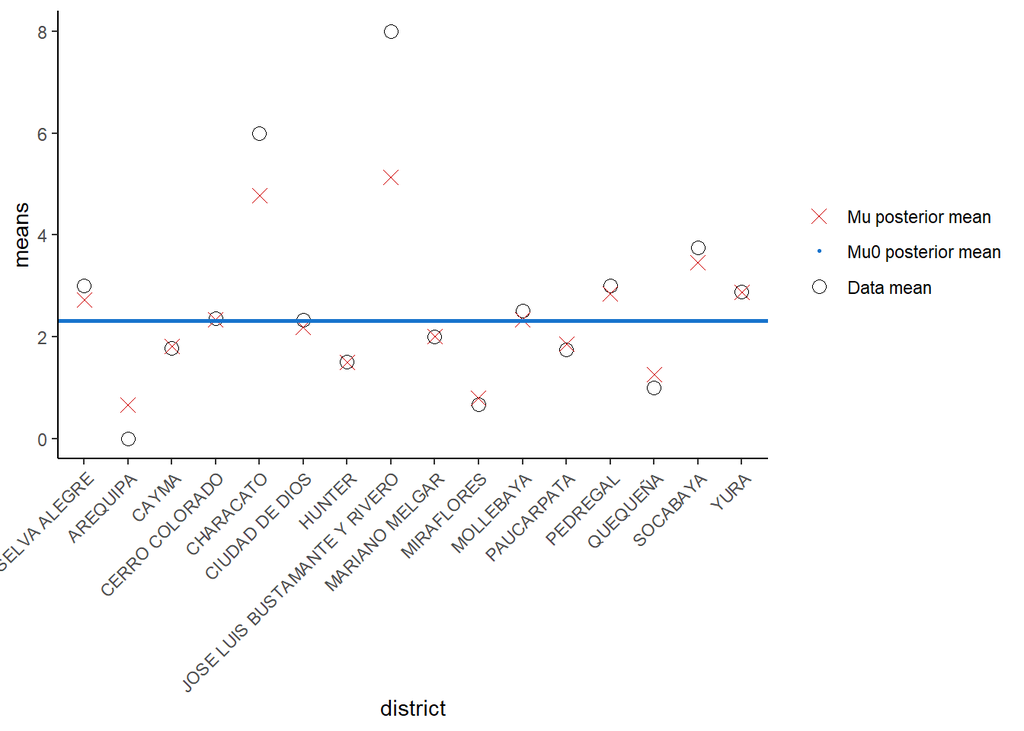

**Figure 7: Shrinkage of normal means.**

**Table 2: modeled means versus data means**

| District | Data mean | number of observations | Posterior mean, $\mu_j$ |
| --- | --- | --- | --- |
| ALTO SELVA ALEGRE | 3.00 | 3 | 2.73 |
| AREQUIPA | 0.00 | 2 | 0.66 |
| CAYMA | 1.78 | 9 | 1.81 |
| CERRO COLORADO | 2.35 | 123 | 2.33 |
| CHARACATO | 6.00 | 2 | 4.77 |
| CIUDAD DE DIOS | 2.33 | 3 | 2.19 |
| HUNTER | 1.50 | 4 | 1.49 |
| JOSE LUIS BUSTAMANTE Y RIVERO | 8.00 | 1 | 5.13 |
| MARIANO MELGAR | 2.00 | 9 | 2.01 |
| MIRAFLORES | 0.67 | 3 | 0.79 |
| MOLLEBAYA | 2.50 | 4 | 2.33 |
| PAUCARPATA | 1.75 | 4 | 1.85 |
| PEDREGAL | 3.00 | 9 | 2.85 |
| QUEQUEÑA | 1.00 | 1 | 1.26 |
| SOCABAYA | 3.75 | 4 | 3.45 |
| YURA | 2.88 | 16 | 2.87 |

## Model Evaluation

The hierarchical model was evaluated using a Bayesian posterior predictive check. To evaluate whether the observed data look extreme compared to data generated from the model, a test statistic not directly evaluated by the model was selected - max($\mu_j$). The maximum district mean, $\mu_j$, observed was compared to the simulated maximum $\mu_j$’s. The observed maximum is not significantly extreme indicating a reasonable model, especially considering an important property of the hierarchical model is to shrink extreme values that are not supported by a large sample.

```r
## Test statistic: max of mu_j from observed data
test.data <- max(df.district$mean)

# max mu_j's from simulated samples
max.mu.samp <- NULL
for(i in 1:nrow(mu.samp)){
  max <- max(mu.samp[i,])
  max.mu.samp <- rbind(max.mu.samp, max)
}

test2.p <- sum(max.mu.samp > test.data)/nrow(mu.samp)
```

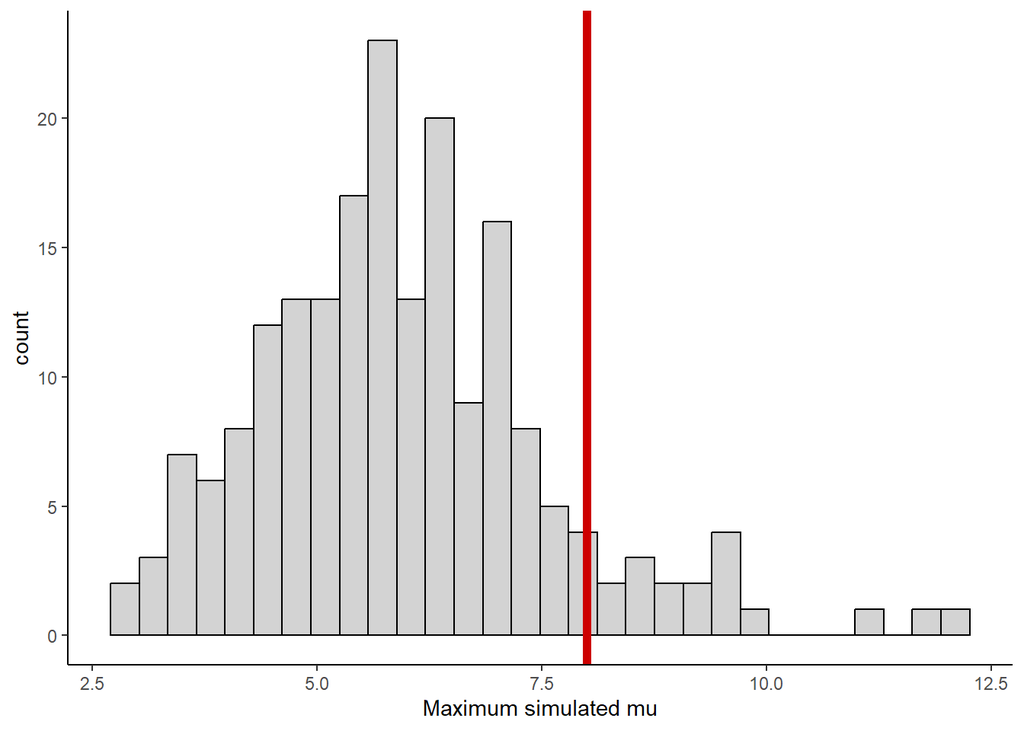

**Figure 8: The distribution of simulated maximum $mu_j$ with the observed maximum $mu_j$ indicated by the red line.**